#### T8

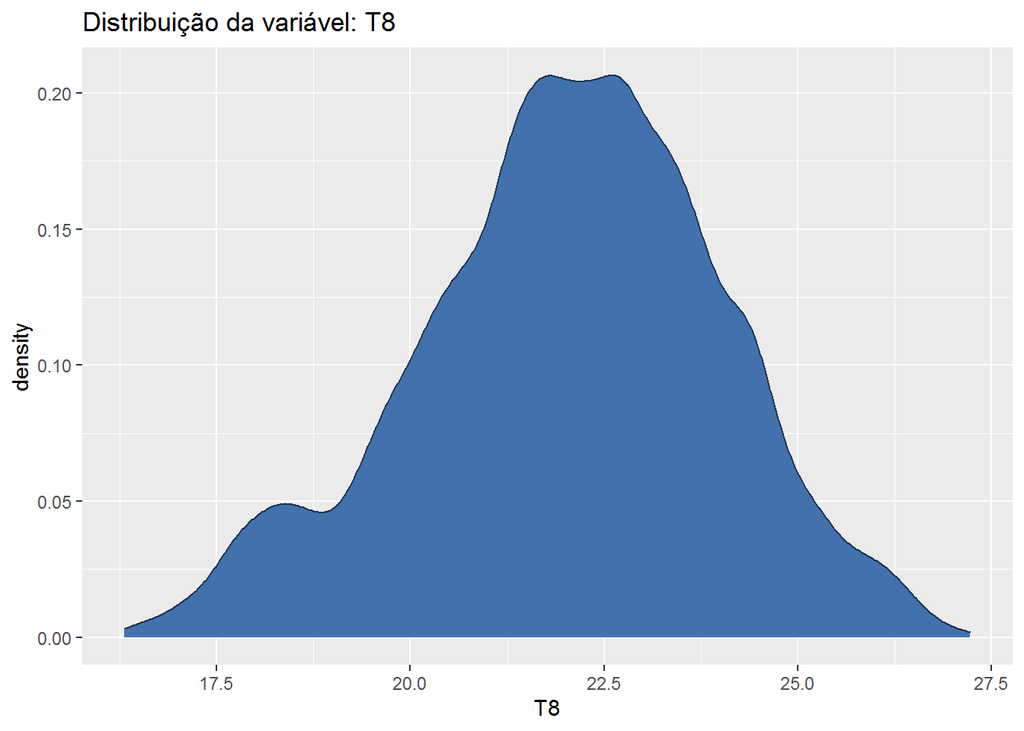

```r
dist_plot(data = df_train, col = 'T8')
```

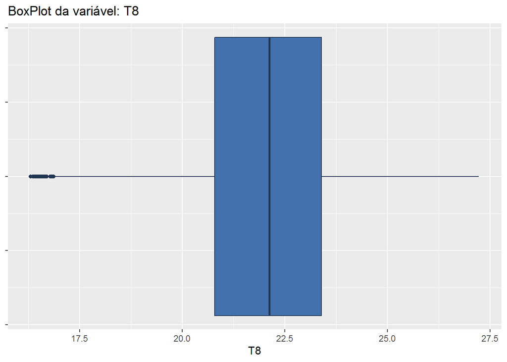

```r
box_plot(data = df_train,col = 'T8')
```

Com o distplot podemos ver que os dados quase simétricos e poucos outliers na borda esquerda como podemos ver com o boxplot.

#### RH_8

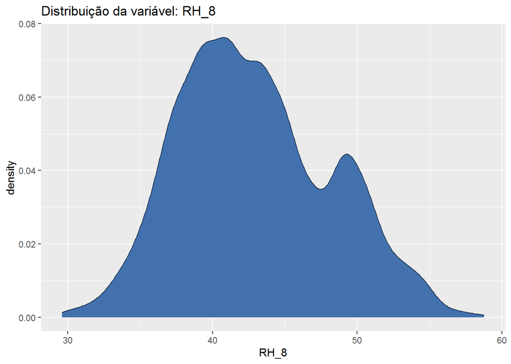

```r
dist_plot(data = df_train, col = 'RH_8')
```

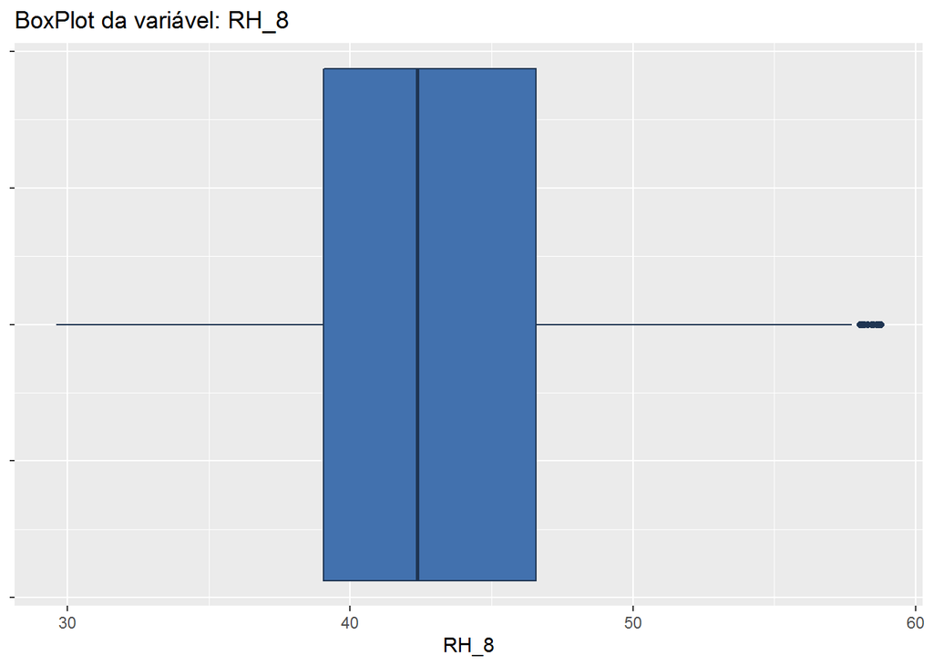

```r
box_plot(data = df_train,col = 'RH_8')
```

Com o distplot podemos ver que os dados estão bem distribuídos e poucos outliers.

#### T9

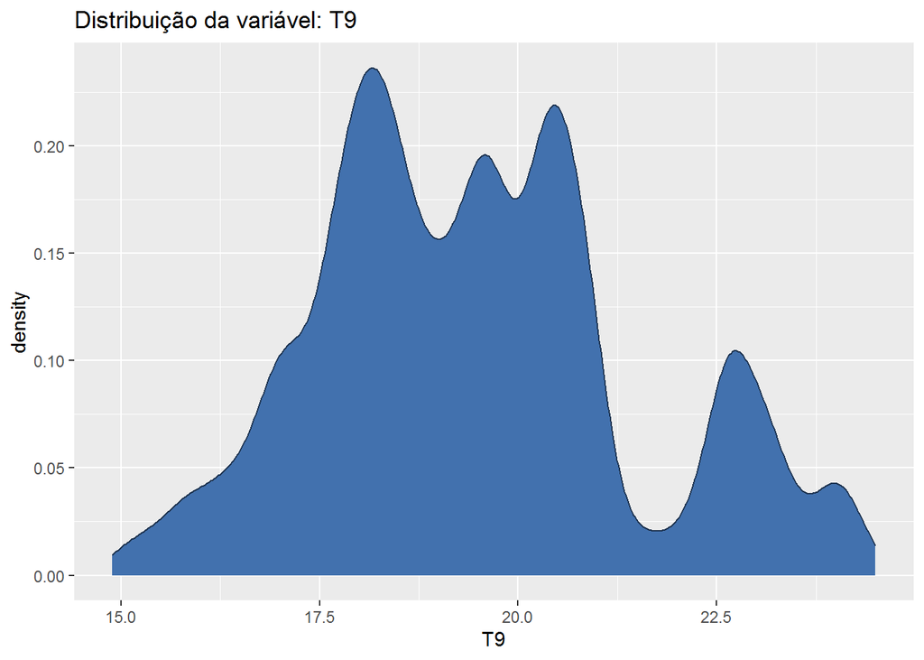

```r
dist_plot(data = df_train, col = 'T9')
```

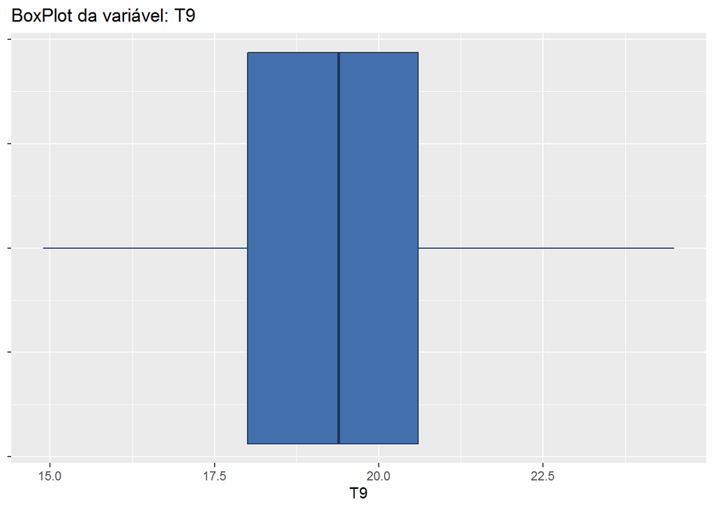

```r
box_plot(data = df_train,col = 'T9')
```

Com o distplot podemos ver que os dados estão bem distribuídos e nenhum outlier visto com o boxplot.

#### RH_9

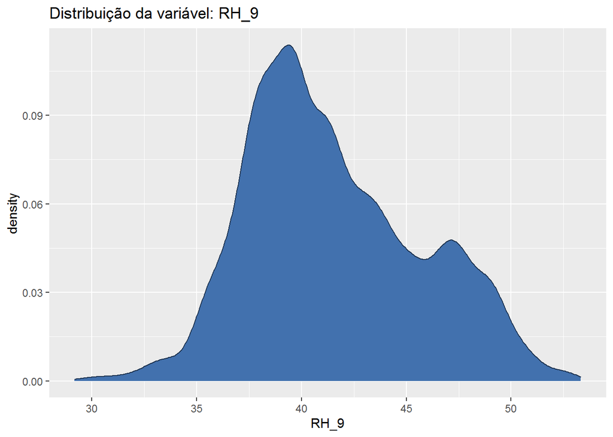

```r
dist_plot(data = df_train, col = 'RH_9')
```

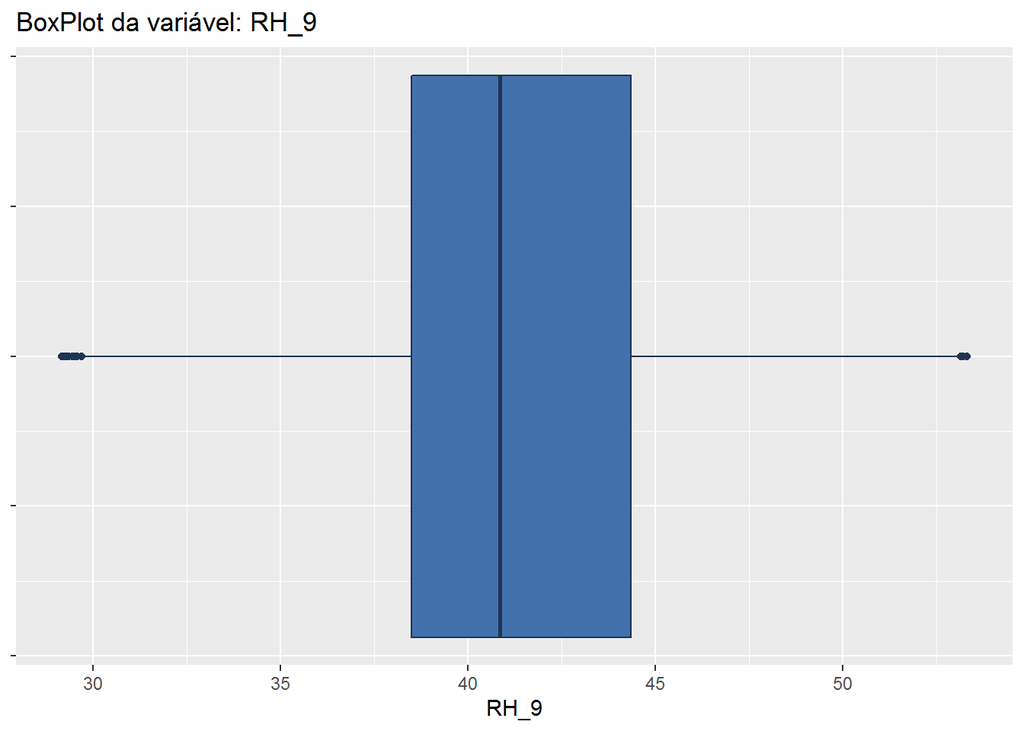

```r
box_plot(data = df_train,col = 'RH_9')
```

Com o distplot podemos ver que os dados tendem um pouco a direita, e tempos alguns outliers como visto com o boxplot.

#### T_out

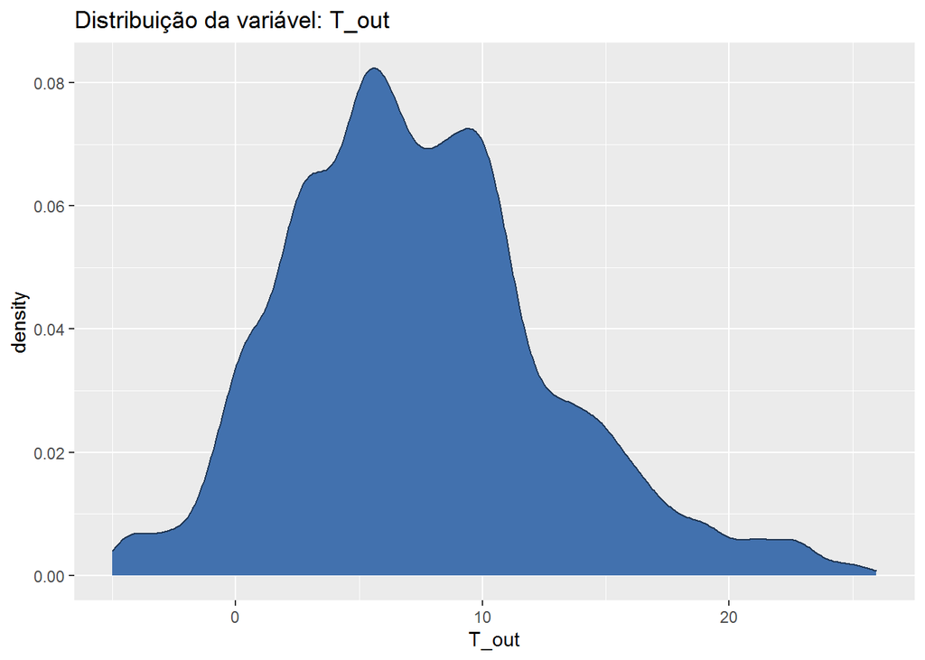

```r
dist_plot(data = df_train, col = 'T_out')
```

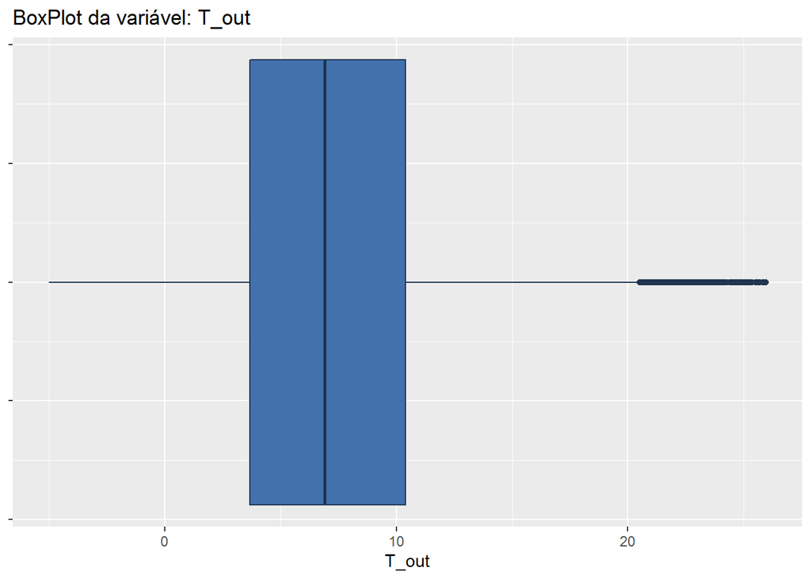

```r
box_plot(data = df_train,col = 'T_out')
```

Com o distplot podemos ver que os dados tendem um pouco a esquerda, e tempos alguns outliers como visto com o boxplot na borda direita.

#### RH_out

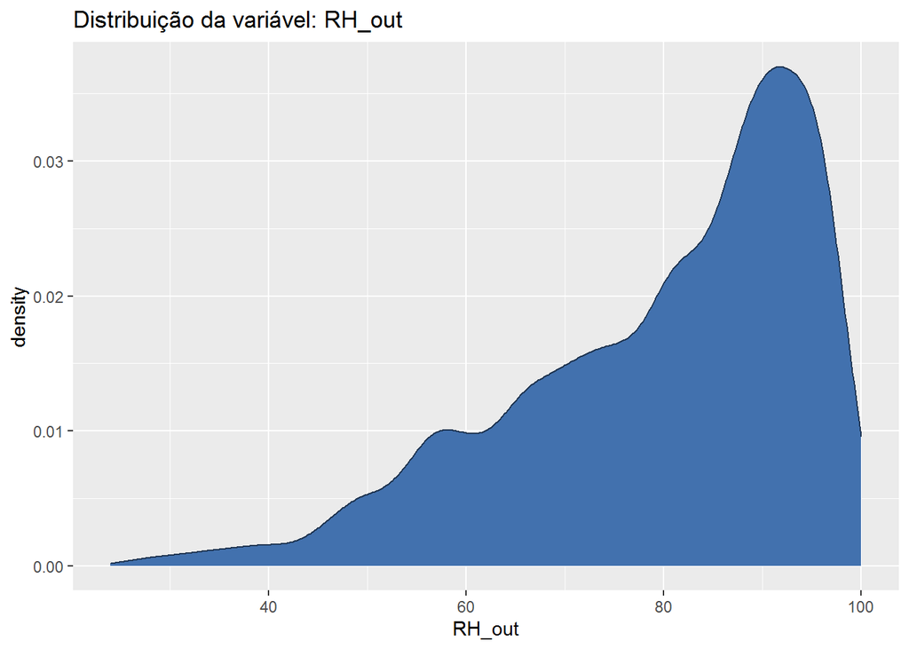

```r
dist_plot(data = df_train, col = 'RH_out')
```

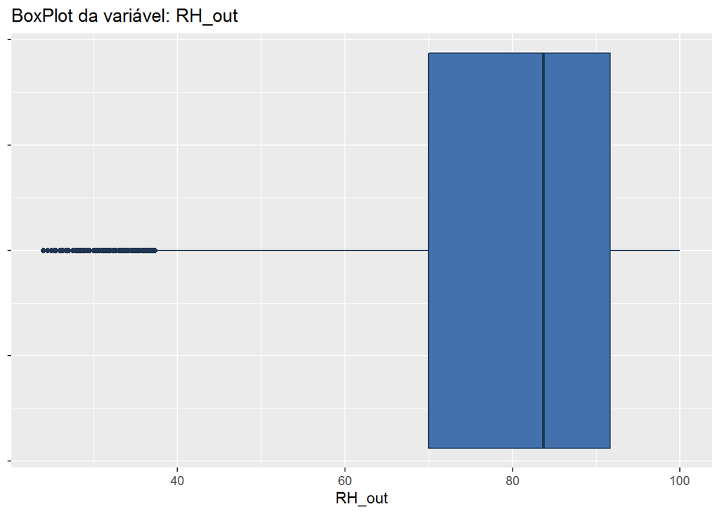

```r
box_plot(data = df_train,col = 'RH_out')
```

Com o distplot podemos ver uma assimetria nos dados, onde se encontram mais na parte direita, e com a ajuda do boxplot podemos ver outliers a na borda esquerda.

#### Press_mm_hg

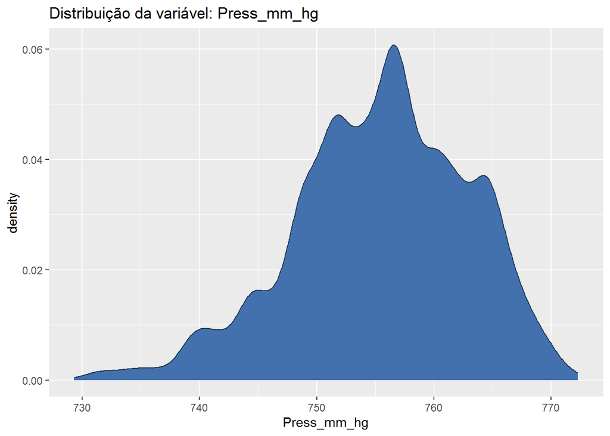

```r
dist_plot(data = df_train, col = 'Press_mm_hg')
```

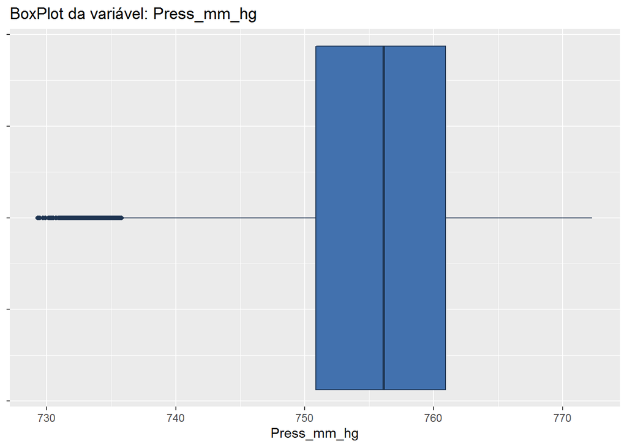

```r
box_plot(data = df_train,col = 'Press_mm_hg')
```

Com o distplot podemos ver uma assimetria nos dados, onde se encontram mais na parte direita, e com a ajuda do boxplot podemos ver outliers a na borda esquerda.

#### Windspeed

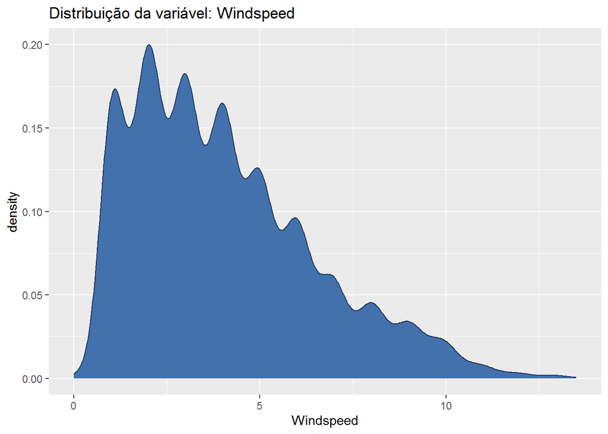

```r
dist_plot(data = df_train, col = 'Windspeed')
```

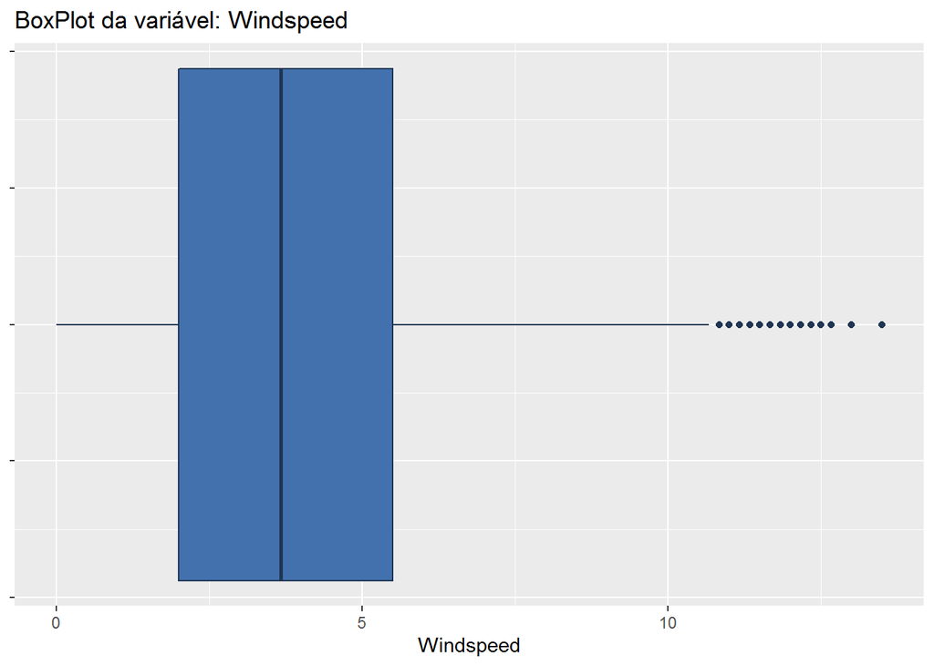

```r
box_plot(data = df_train,col = 'Windspeed')
```

Com o distplot podemos ver que os dados tendem um pouco a esquerda, e tempos alguns outliers como visto com o boxplot na borda direita.

#### Visibility

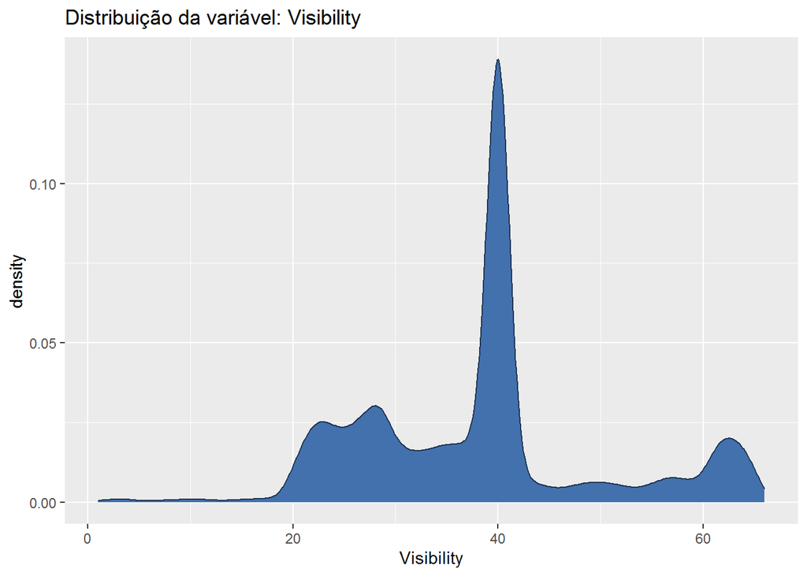

```r
dist_plot(data = df_train, col = 'Visibility')
```

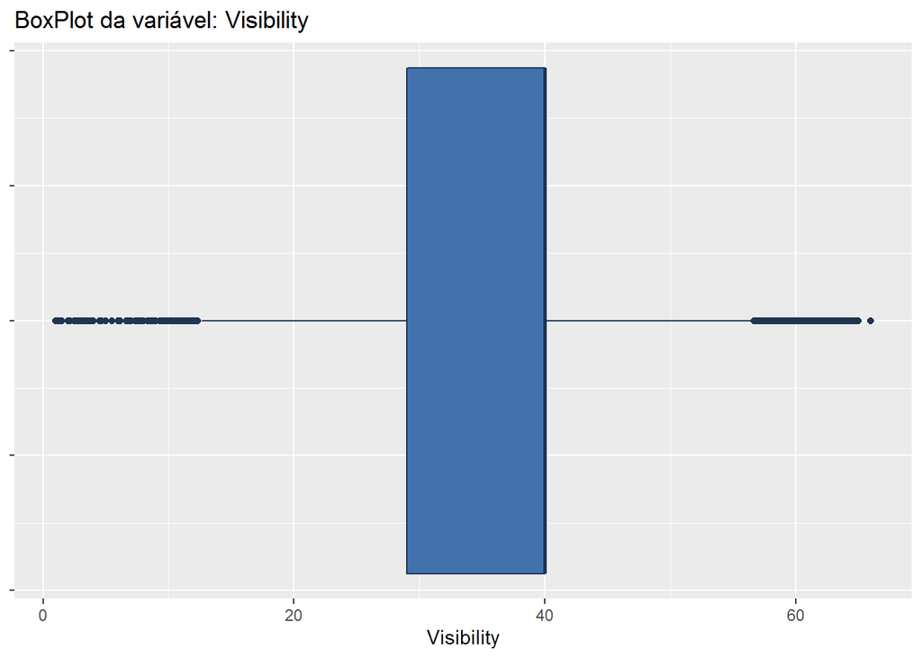

```r
box_plot(data = df_train,col = 'Visibility')
```

#### Tdewpoint

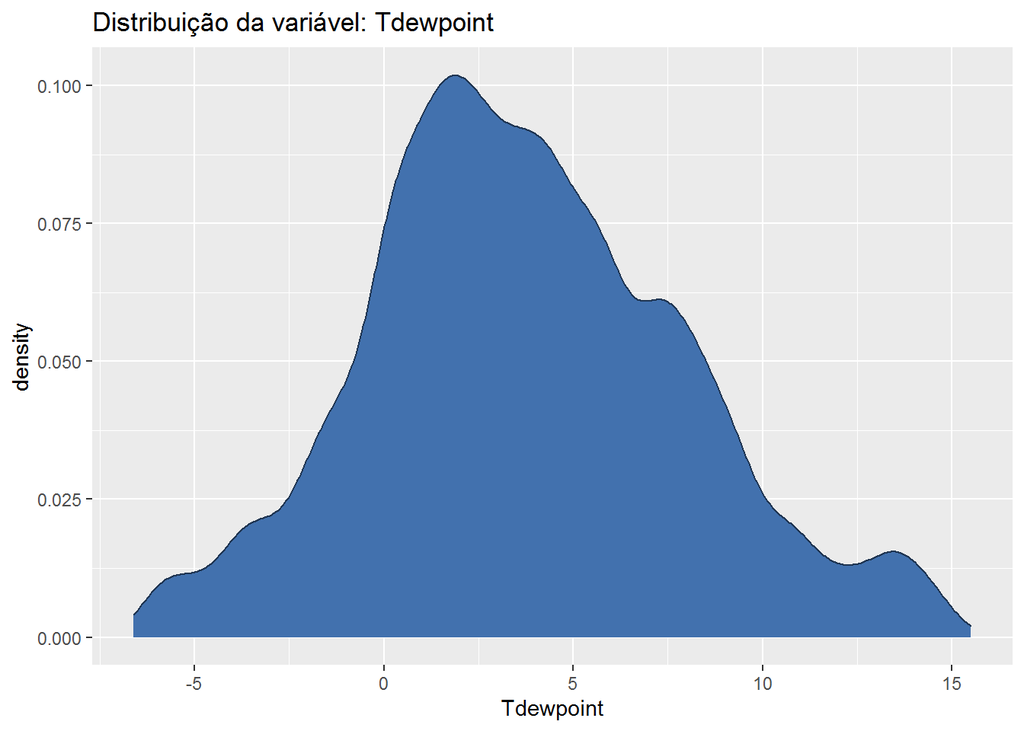

```r
dist_plot(data = df_train, col = 'Tdewpoint')
```

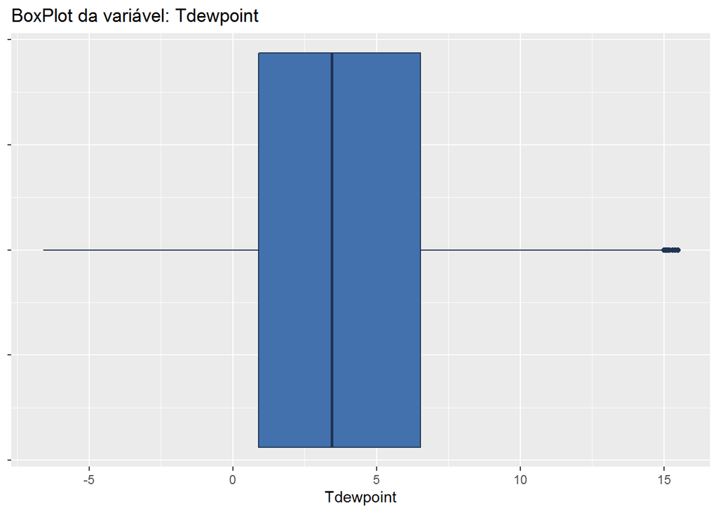

```r
box_plot(data = df_train,col = 'Tdewpoint')
```

#### rv1

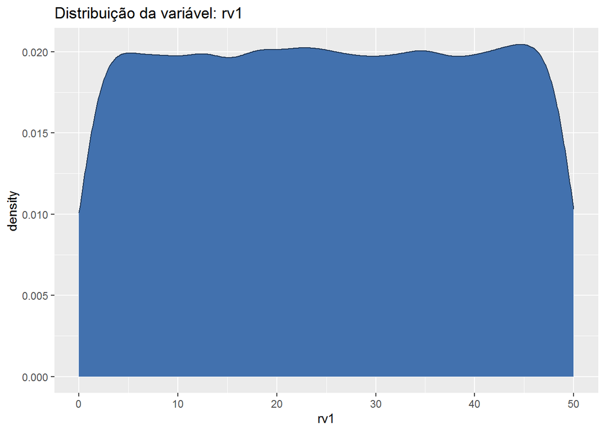

```r
dist_plot(data = df_train, col = 'rv1')
```

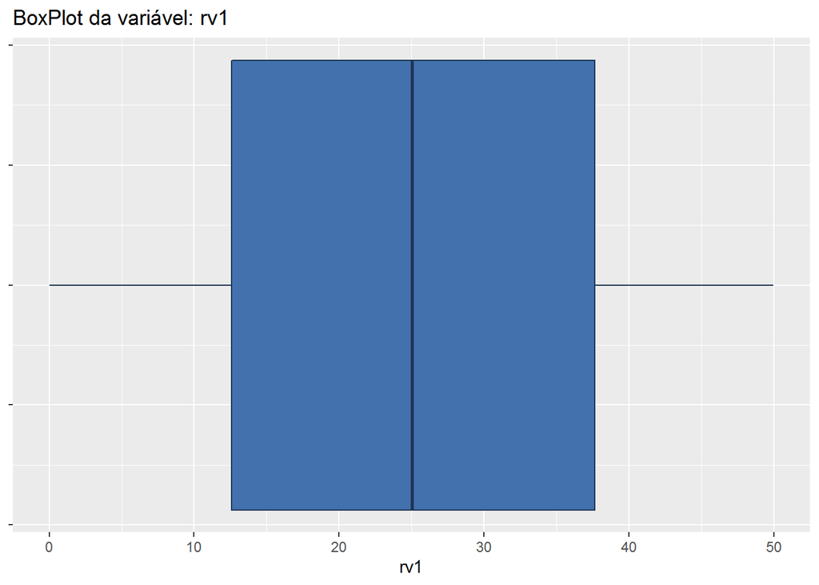

```r
box_plot(data = df_train,col = 'rv1')
```

Com o distplot podemos ver que os dados estão completamente distribuídos boxplot vemos que não tem outliers.

#### rv2

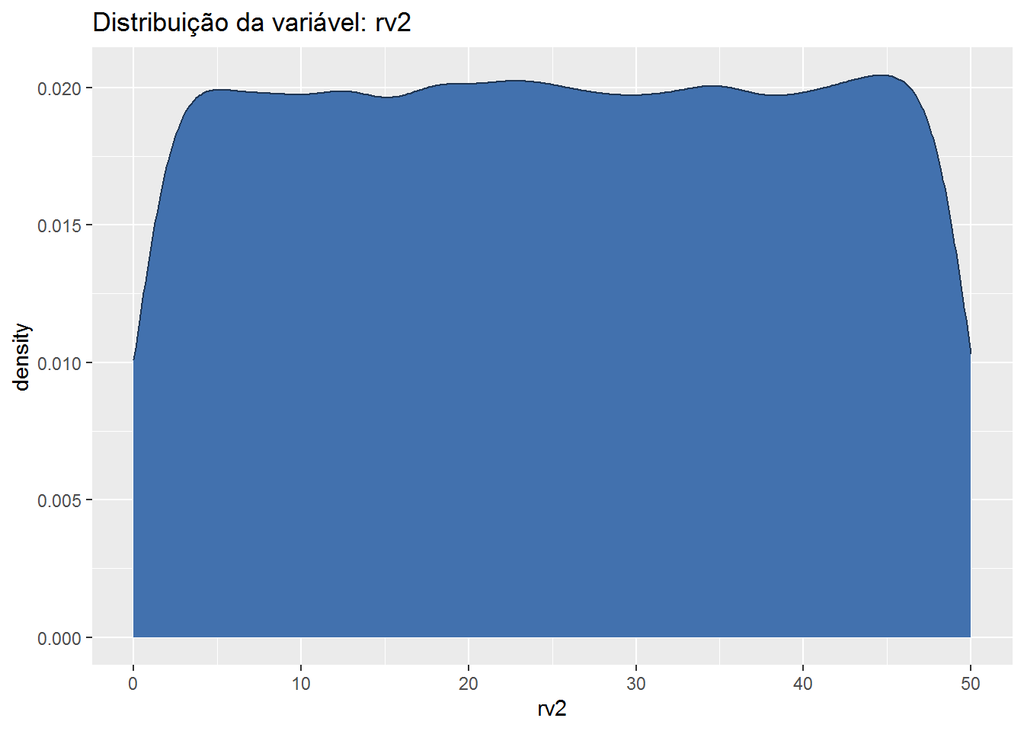

```r
dist_plot(data = df_train, col = 'rv2')
```

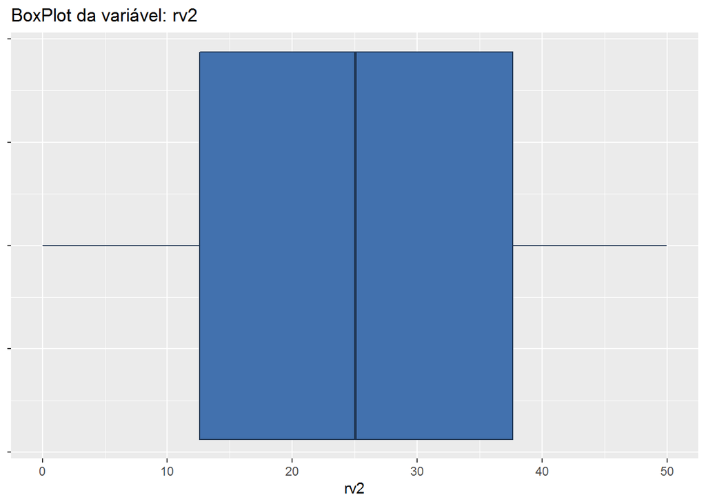

```r
box_plot(data = df_train,col = 'rv2')
```

Com o distplot podemos ver que os dados estão completamente distribuídos boxplot vemos que não tem outliers.

#### NSM

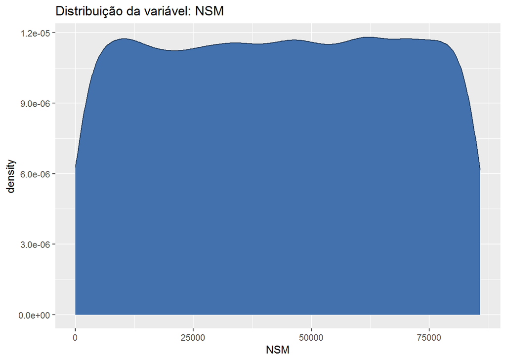

```r
dist_plot(data = df_train, col = 'NSM')
```

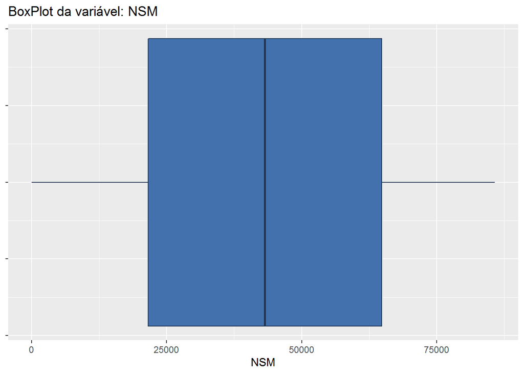

```r
box_plot(data = df_train,col = 'NSM')
```

Com o distplot podemos ver que os dados estão completamente distribuídos boxplot vemos que não tem outliers.

#### WeekStatus

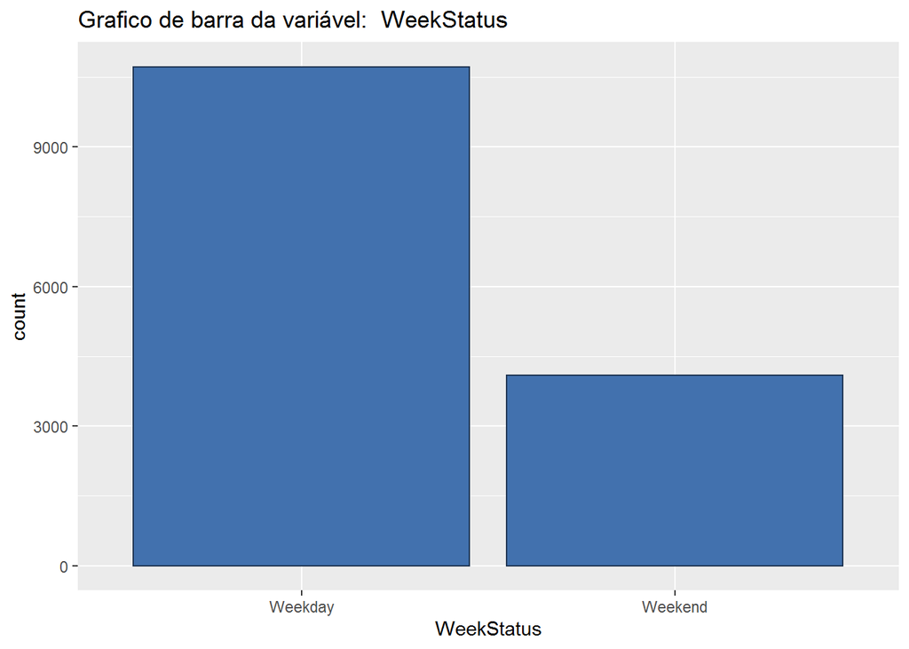

```r
bar_plot(df_train, 'WeekStatus')
```

Temos mais dados coletados durante a semana do que final de semana, como já esperado já que temos mais dias durante a semana e foi coletado dados em dias corridos.

#### Day_of_week

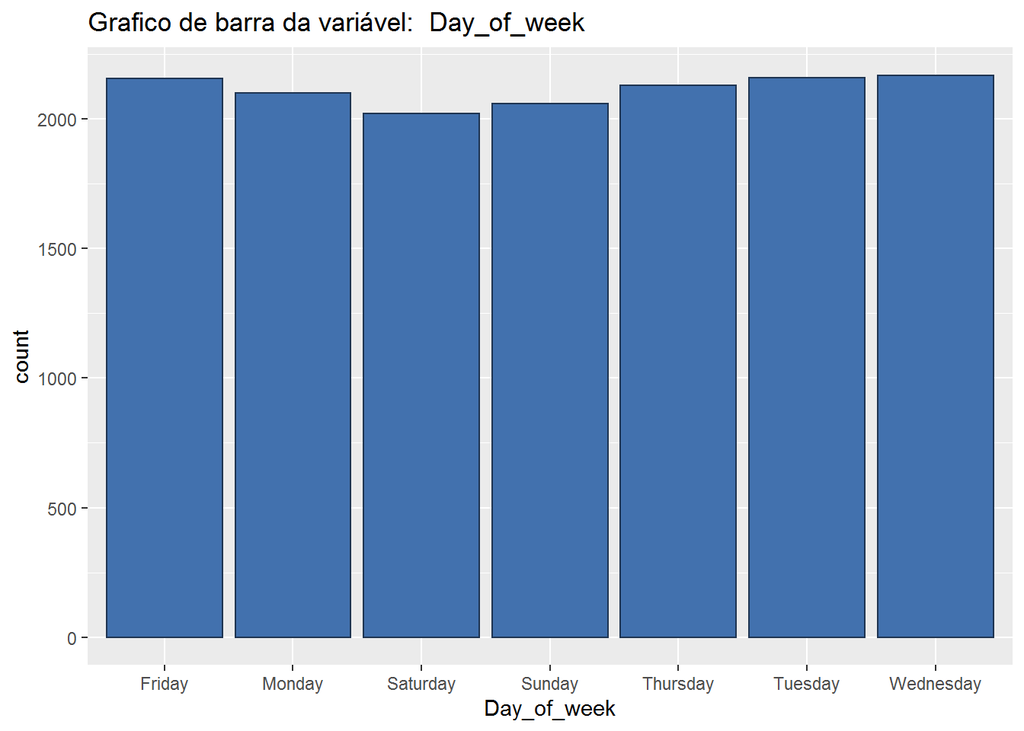

```r
bar_plot(df_train, 'Day_of_week')
```

A distribuição dos dados coletados por dia está totalmente equilibrada.

#### Month

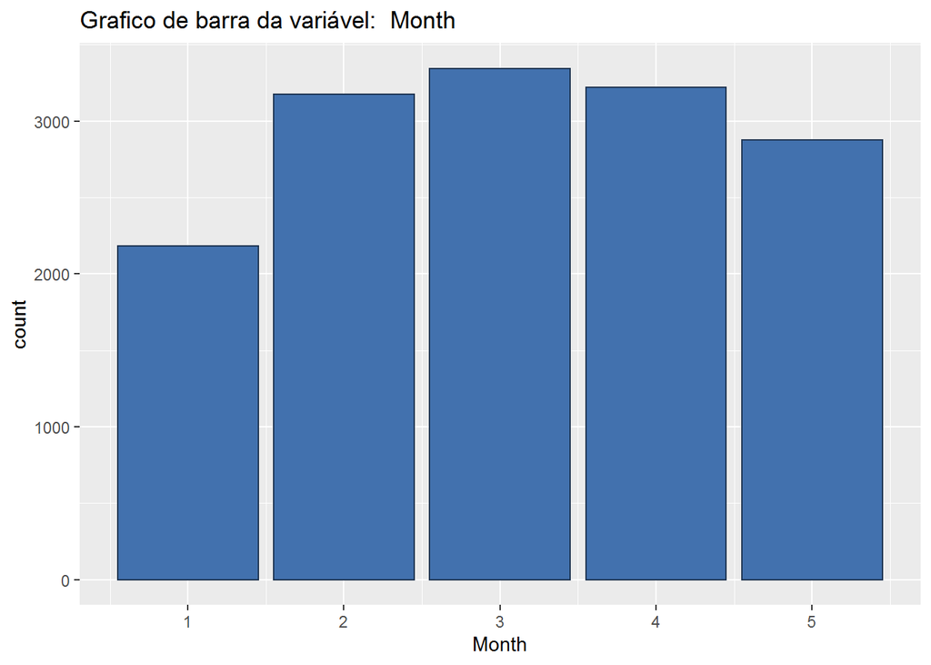

```r
bar_plot(df_train, 'Month')
```

A distribuição dos dados coletados por mês mostra que o mês de marco foi o que mais teve dados, e o de janeiro menos.

#### Day

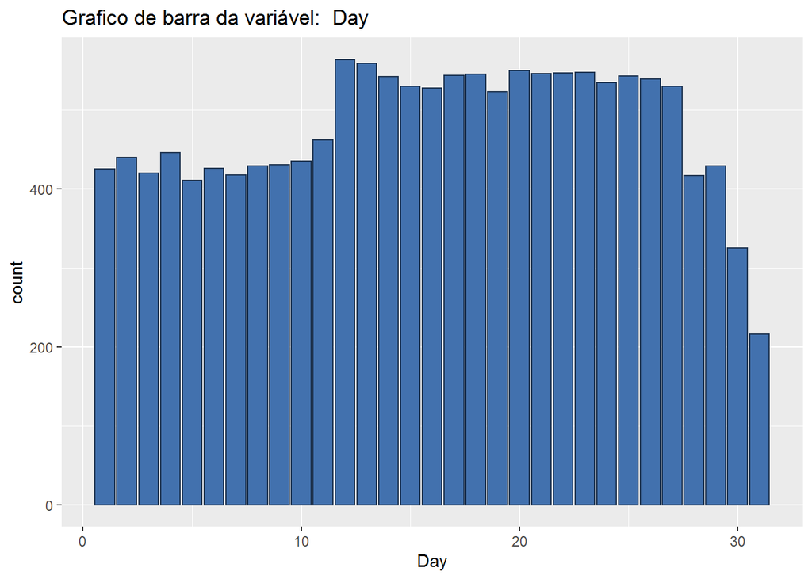

```r
bar_plot(df_train, 'Day')
```

Do meio para o final do mes aumenta a contabilização de dados coletados.

#### Quantidade total de energia gasta por mês

```r
df_train %>%
  select(Appliances,Month)%>%
  group_by(Month)%>%
  summarise(sum(Appliances))
```

```
## # A tibble: 5 x 2
##   Month `sum(Appliances)`
##   <int>             <dbl>
## 1     1            209600
## 2     2            321280
## 3     3            322210
## 4     4            322930
## 5     5            274840
```

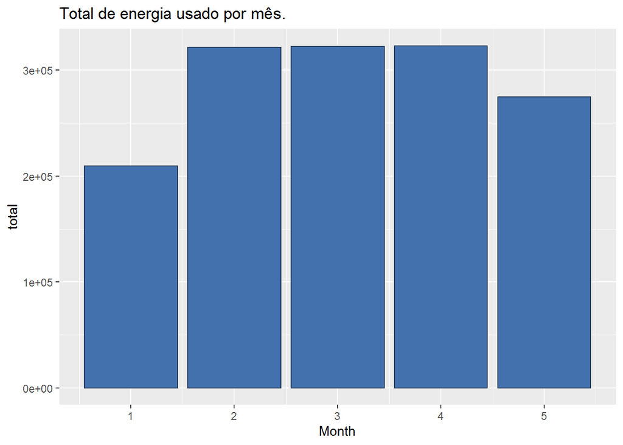

```r
df_train %>%
  select(Appliances,Month)%>%
  group_by(Month)%>%
  summarise(total = sum(Appliances))%>%
  ggplot()+
  geom_bar(aes (x = Month, y= total),stat = "identity",color = "#1F3552", fill = "#4271AE") +
  labs( title = paste('Total de energia usado por mês.'))
```

Fevereiro, março e abril teve o mesmo consumo total, seguidos um pouco mais baixo maio e janeiro respectivamente.

#### Quantidade total de energia gasta por dia

```r
df_train %>%
  select(Appliances,Day)%>%
  group_by(Day)%>%
  summarise(sum(Appliances))
```

```
## # A tibble: 31 x 2
##      Day `sum(Appliances)`
##    <int>             <dbl>
##  1     1             40650
##  2     2             33790
##  3     3             37250
##  4     4             53330
##  5     5             37770
##  6     6             39080
##  7     7             42490
##  8     8             47270
##  9     9             43390
## 10    10             37310
## # ... with 21 more rows
```

[figure not shown]

```r
df_train %>%
  select(Appliances,Day)%>%
  group_by(Day)%>%
  summarise(total = sum(Appliances))%>%
  ggplot()+
  geom_bar(aes (x = Day, y= total),stat = "identity",color = "#1F3552", fill = "#4271AE") +
  labs( title = paste('Total de energia usado por mês.'))
```

Podemos notar um aumento de consumo de energia no meio do mês, entre os dias 12 a 17.

#### Quantidade total de energia gasta separando por dia da semana e final de semana.

```r
df_train %>%
  select(Appliances,WeekStatus)%>%
  group_by(WeekStatus)%>%
  summarise(total = sum(Appliances))
```

```
## # A tibble: 2 x 2
##   WeekStatus   total
##   <chr>        <dbl>
## 1 Weekday    1035590
## 2 Weekend     415270
```

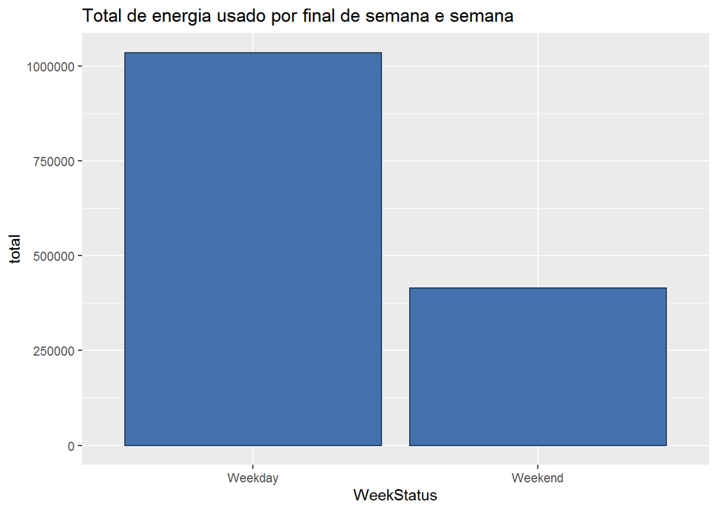

```r
df_train %>%
  select(Appliances,WeekStatus)%>%
  group_by(WeekStatus)%>%
  summarise(total = sum(Appliances))%>%
  ggplot()+
  geom_bar(aes (x = WeekStatus, y= total),stat = "identity",color = "#1F3552", fill = "#4271AE") +
  labs( title = paste('Total de energia usado por final de semana e semana'))
```

Como já era de se esperava o consumo total durante a semana é o dobro do final de semana.

#### Quantidade total de energia gasta por dia da semana

```r
df_train %>%
  select(Appliances,Day_of_week)%>%
  group_by(Day_of_week)%>%
  summarise(total = sum(Appliances))
```

```
## # A tibble: 7 x 2
##   Day_of_week  total
##   <chr>        <dbl>
## 1 Friday      224190
## 2 Monday      235300
## 3 Saturday    217010
## 4 Sunday      198260
## 5 Thursday    194830
## 6 Tuesday     187180
## 7 Wednesday   194090
```

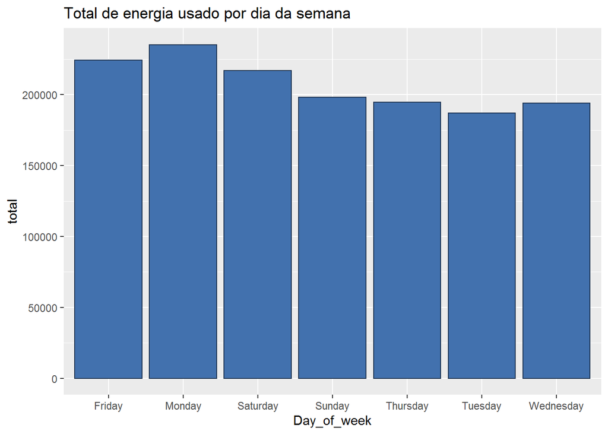

```r
df_train %>%
  select(Appliances,Day_of_week)%>%
  group_by(Day_of_week)%>%
  summarise(total = sum(Appliances))%>%
  ggplot()+
  geom_bar(aes (x = Day_of_week, y= total),stat = "identity",color = "#1F3552", fill = "#4271AE") +
  labs( title = paste('Total de energia usado por dia da semana'))
```

Segunda, sexta e sábado lideram com o maior consumo, seguido dos demais dias que possuem praticamente o mesmo consumo.

#### Quantidade total de energia gasta por hora

```r
df_train %>%
  select(Appliances,Hour)%>%
  group_by(Hour)%>%
  summarise(total = sum(Appliances))
```

```
## # A tibble: 24 x 2
##     Hour total
##    <int> <dbl>
##  1     0 32860
##  2     1 31100
##  3     2 30710
##  4     3 30380
##  5     4 29910
##  6     5 30810
##  7     6 34360
##  8     7 49190
##  9     8 64580
## 10     9 71400
## # ... with 14 more rows
```

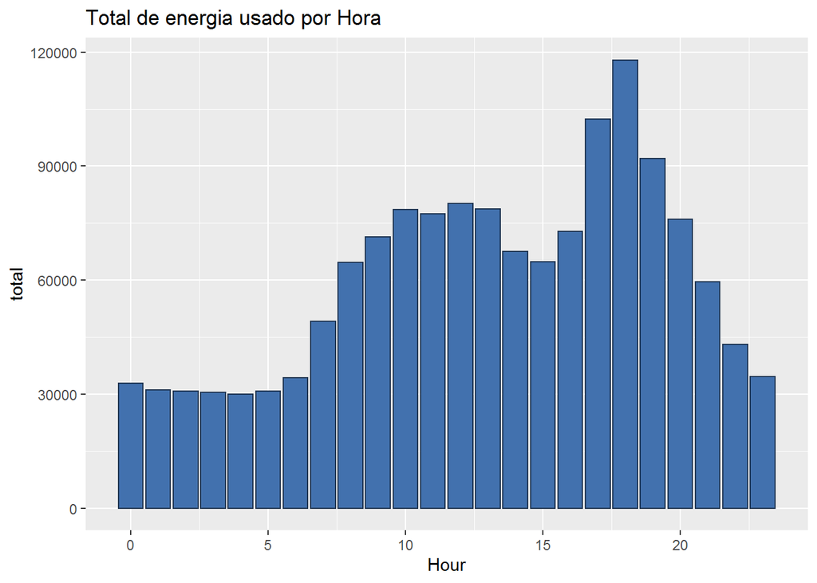

```r
df_train %>%
  select(Appliances,Hour)%>%
  group_by(Hour)%>%
  summarise(total = sum(Appliances))%>%
  ggplot()+
  geom_bar(aes (x = Hour, y= total),stat = "identity",color = "#1F3552", fill = "#4271AE") +
  labs( title = paste('Total de energia usado por Hora'))
```

A parte da noite entre 17:00 a 19:00 são os horários com maiores consumos, um indicio é o fato de a maioria das pessoas chegarem em casa por essa hora do trabalho, então com mais pessoas na cada o uso aumenta.

#### Quantidade total de energia gasta por minuto

```r
df_train %>%
  select(Appliances,Minute)%>%
  group_by(Minute)%>%
  summarise(total = sum(Appliances))
```

```
## # A tibble: 6 x 2
##   Minute  total
##    <int>  <dbl>
## 1      0 240370
## 2     10 234130
## 3     20 242630
## 4     30 244440
## 5     40 245420
## 6     50 243870
```

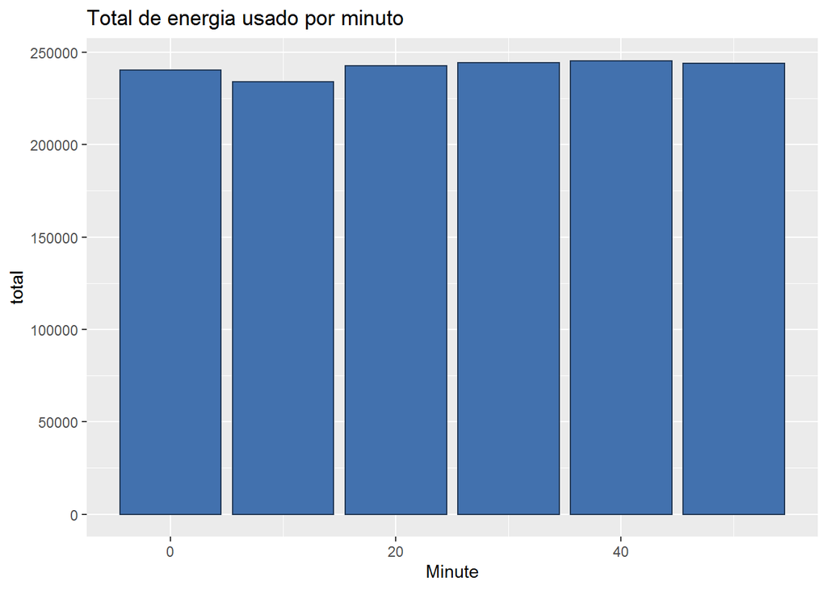

```r
df_train %>%
  select(Appliances,Minute)%>%
  group_by(Minute)%>%
  summarise(total = sum(Appliances))%>%
  ggplot()+
  geom_bar(aes (x = Minute, y= total),stat = "identity",color = "#1F3552", fill = "#4271AE") +
  labs( title = paste('Total de energia usado por minuto'))
```

Não há diferente no uso de energia com relação os minutos que foram feitos o registro.

#### Quantida total de energia gasta separando por potencia dos eletrodomesticos.

```r
df_train %>%
  select(Appliances,lights)%>%
  group_by(lights)%>%
  summarise(total = sum(Appliances))
```

```
## # A tibble: 6 x 2
##   lights  total
##    <dbl>  <dbl>
## 1      0 995830
## 2     10 210180
## 3     20 171670
## 4     30  60790
## 5     40  10840
## 6     50   1550
```

[figure not shown]

```r
df_train %>%
  select(Appliances,lights)%>%
  group_by(lights)%>%
  summarise(total = sum(Appliances))%>%
  ggplot()+
  geom_bar(aes (x = lights, y= total),stat = "identity",color = "#1F3552", fill = "#4271AE") +
  labs( title = paste('Total de energia usado por minuto'))
```

Podemos notar que o total de consumo não está diretamente ligado com o valor da potência para cada eletrodoméstico pois o com potência com nomeação 0 no DataFrame é o que mais tem consumo.

Com essas analises podemos tirar alguns insights e conhecimento sobre os dados e seus relacionamentos.

## Tratamento dos dados

Aqui faremos alguns tratamentos nos dados, como tratamento dos outliers da target, normalização dos dados, criação de variáveis label, verificar a correlação entre as variáveis.

```r
# Converto para valor binário (0,1) onde 1 representa dias da semana e 0 dias do final de semana.
df_train$WeekStatus <- ifelse(df_train$WeekStatus == 'Weekend',0,1)

# Função para converter o label dia da semana para numero.
 LabelEncoder<- function(var) {
   if( var == 'Sunday'){
     var = 1
   }
   else if( var == 'Monday'){
     var = 2
   }
   else if( var == 'Tuesday'){
     var = 3
   }
   else if( var == 'Wednesday'){
     var = 4
   }
   else if( var == 'Thursday'){
     var = 5
   }
   else if( var == 'Friday'){
     var = 6
   }
   else if( var == 'Saturday'){
     var = 7
   }

}
# Aplico convertendo a variável.
df_train$Day_of_week <- sapply(df_train$Day_of_week, LabelEncoder)
# Verifico se foi gerado algum valor nulo.
sum(is.na(df_train))
```

```
## [1] 0
```

Como vimos na analise exploratória, a variável appliances(target) possue valores outliers, e isso pode prejudiar o modelo, então iremos trata-los agora.

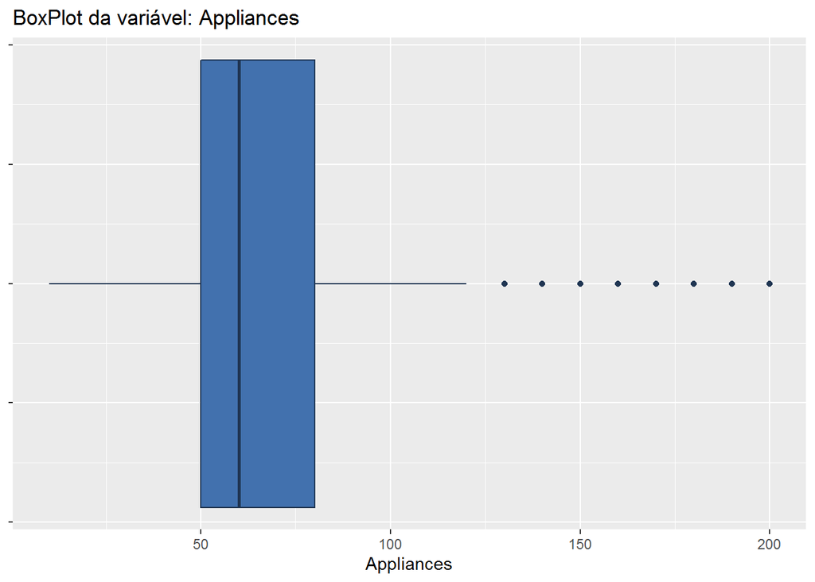

```r
# Irei  restringir a target em valores menores que 0.90 quartil
quart90 <- quantile(df_train$Appliances, probs = 0.90)

# Aplico o filtro para tirar diminuir os outliers
df_train_out_t <-df_train[df_train$Appliances<=quart90[[1]],]

# Plot do mesmo grafico vis antes agora com menos outliers
box_plot(data = df_train_out_t,col = "Appliances")
```

```r
#sumario estatisco da target agora tratada.
summary(df_train_out_t["Appliances"])
```

```
##    Appliances
##  Min.   : 10.00
##  1st Qu.: 50.00
##  Median : 60.00
##  Mean   : 68.64
##  3rd Qu.: 80.00
##  Max.   :200.00
```

```r
# Retiro a variável date
df_train_out_t$date <- NULL
```

## Normalização dos dados

```r
normalize <- function(x) {
  return ((x - min(x)) / (max(x) - min(x)))
}
# Crio um DataFrame so das variáveis normalizadas
names(df_train_out_t[,1:29])
```

```
##  [1] "Appliances"  "lights"      "T1"          "RH_1"        "T2"
##  [6] "RH_2"        "T3"          "RH_3"        "T4"          "RH_4"
## [11] "T5"          "RH_5"        "T6"          "RH_6"        "T7"
## [16] "RH_7"        "T8"          "RH_8"        "T9"          "RH_9"
## [21] "T_out"       "Press_mm_hg" "RH_out"      "Windspeed"   "Visibility"
## [26] "Tdewpoint"   "rv1"         "rv2"         "NSM"
```

```r
data_norm <- as.data.frame(sapply(df_train_out_t[,1:29], normalize))
```

```r
# Correlação das variáveis
correlacao <- cor(data_norm)
correlacao[1,]
```

```
##   Appliances       lights           T1         RH_1           T2         RH_2
##  1.000000000  0.276933739  0.224515771  0.060656595  0.245819094 -0.093940732
##           T3         RH_3           T4         RH_4           T5         RH_5
##  0.169498390 -0.068901479  0.178547985 -0.025352291  0.168282211  0.061608062
##           T6         RH_6           T7         RH_7           T8         RH_8
##  0.212307645 -0.216713932  0.155394984 -0.115226361  0.235186419 -0.198616453
##           T9         RH_9        T_out  Press_mm_hg       RH_out    Windspeed
##  0.137718546 -0.177750584  0.200937361 -0.086961260 -0.237042661  0.060306495
##   Visibility    Tdewpoint          rv1          rv2          NSM
## -0.032408382  0.077750705 -0.009287457 -0.009287457  0.390787903
```

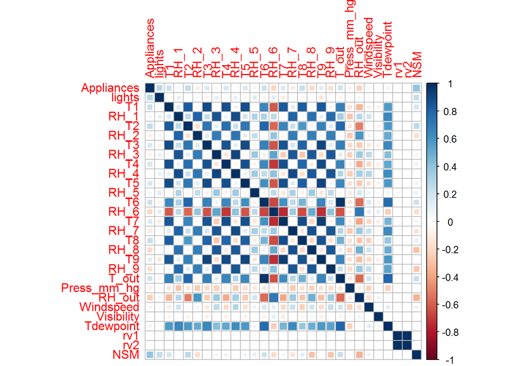

```r
corrplot(correlacao,  method = 'square')
```

## Feature Selection (Seleção de Variáveis)

Usarei o modelo randomForest e para seleção das melhores variáveis.

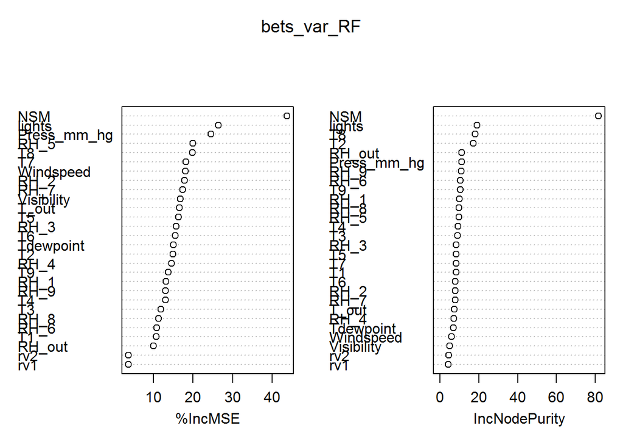

```r
bets_var_RF <- randomForest(Appliances  ~ . ,data = data_norm,
                            ntree = 100, nodesize = 10, importance = T)

varImpPlot(bets_var_RF)
```

Analisando as importâncias para o modelo e juntamente com a correlação separei as variáveis abaixo para o treinamento dos modelos.

```r
# Crio o vetor com as variáveis mais importantes para filtragem na criação do novo DataFrame.
best_var <- c('Appliances','T2','NSM','lights', 'RH_6','RH_out','Tdewpoint')

# Crio o DataFrame final que sera usado nos modelos preditivos.
train_pred <- data_norm[best_var]
head(train_pred)
```

```
##   Appliances        T2       NSM lights      RH_6    RH_out Tdewpoint
## 1  0.2631579 0.2253453 0.7132867    0.6 0.8418268 0.8947368 0.5384615
## 2  0.2631579 0.2253453 0.7202797    0.6 0.8398719 0.8947368 0.5339367
## 3  0.2105263 0.2253453 0.7272727    0.6 0.8307044 0.8947368 0.5294118
## 4  0.2631579 0.2253453 0.7412587    0.8 0.8482642 0.8947368 0.5203620
## 5  0.2105263 0.2253453 0.7482517    0.8 0.8570947 0.8947368 0.5158371
## 6  0.2631579 0.2253453 0.7622378    1.0 0.8637344 0.8925439 0.5105581
```

## Split dos dados

```r
# Faço uma divisão de 80/20 para dados de treino e teste.
split = sample.split(train_pred$lights, SplitRatio = 0.80)
train = subset(train_pred, split == TRUE)
test = subset(train_pred, split == FALSE)

# imprimo as Dimensões
dim(train)
```

```
## [1] 10676     7
```

```r
dim(test)
```

```
## [1] 2669    7
```

## Algoritmos de aprendizagem ( Regressão )

```r
# Modelo svm do pacote library(e1071)
# ?svm

modelo_svm <- svm(Appliances ~ .
                 ,data= train,type = 'eps-regression',kernel = 'radial',
                 cost = 10, scale = FALSE,gamma = 0.1)
previsao_svm <- predict(modelo_svm, test)


# Accuracy
mae = MAE(test$Appliances,previsao_svm)
rmse = RMSE(test$Appliances,previsao_svm)
r2 = R2(test$Appliances,previsao_svm)

cat(" MAE:", mae, "\n",
    "RMSE:", rmse, "\n", "R-squared:", r2)
```

```
##  MAE: 0.0964964
##  RMSE: 0.1348989
##  R-squared: 0.3057909
```

```r
#  Modelo com o randomForest
# ?randomForest

modelo_RF <- randomForest(Appliances ~ .
                  ,data= train,ntree = 60,
                  nodesize = 5)
previsao_RF <- predict(modelo_RF, test)

# Accuracy
mae = MAE(test$Appliances,previsao_RF)
rmse = RMSE(test$Appliances,previsao_RF)
r2 = R2(test$Appliances,previsao_RF)

cat(" MAE:", mae, "\n",
    "RMSE:", rmse, "\n", "R-squared:", r2)
```

```
##  MAE: 0.06820793
##  RMSE: 0.1044598
##  R-squared: 0.5836201
```

```r
#  Modelo com o xgboost
# Para o modelo tenho que converter o DF para uma matrix.
trainxb <- as.matrix(train[2:6])
trainl <- as.matrix(train[1])
testxm <- as.matrix(test[2:6])
testl <- as.matrix(test[1])
# ?xgboost
modelo_XB <- xgboost(data = trainxb,
                     label = trainl ,
                     max.depth = 2,
                     eta = 1,
                     nthread = 2,
                     nround = 2
                     )
previsao_XB <- predict(modelo_XB,testxm)

# Accuracy
mae = MAE(testl,previsao_XB)
rmse = RMSE(testl,previsao_XB)
r2= R2(testl,previsao_XB)

cat(" MAE:", mae, "\n",
    "RMSE:", rmse, "\n", "R-squared:", r2)
```

```
##  MAE: 0.09419443
##  RMSE: 0.134833
##  R-squared: 0.3063674
```

Como podemos notar para um problema de regressão não tivemos uma boa acurácia, isso pode ser por conta dos poucos dados para treinamento, não permitindo que o modelo aprender o suficiente como também as várias colinearidades entre as variáveis que prejudicam os modelos, embora eu tenha separado as que possuem menos colinearidades possível entre elas.

## Algoritmos de aprendizagem ( Classificação )

Como foi dito acima, pelos motivos citados e entre outros a regressão não ficou interessante para o projeto nesse panorama, então tentarei agora uma outra abordagem, onde eu irei transformar esse projeto de regressão em um de classificação, criando variáveis target baseados no valor do uso de energia e veremos se assim teremos uma melhor performance.

Criarei 4 variáveis target, com critérios que eu determinarei da seguinte forma: uso de energia baixo de 60 eu considerarei como variável 1 (baixo), acima de 60 até 100 como variável 2 (médio), acima de 100 até 500 como variável 3 (alto), e o que for acima de 500 como variável 4 ( muito alto.

Irei carrega dos dados novamente e realizar todo o tratamento feito para que não corra risco de ter algum erro.

```r
# Carregano os dados
df_train <- read_csv('Dados/projeto8-training.csv')
df_train <- as.data.frame(df_train)
df_test <- read_csv('Dados/projeto8-testing.csv')
df_test <- as.data.frame(df_test)

# Criando variáveis (mês,dia, hora e minuto)
# df_train
df_train$Month <- sapply(df_train$date, month)
df_train$Day <- sapply(df_train$date, mday)
df_train$Hour <- sapply(df_train$date,hour)
df_train$Minute <- sapply(df_train$date, minute)
# df_test
df_test$Month <- sapply(df_test$date, month)
df_test$Day <- sapply(df_test$date, mday)
df_test$Hour <- sapply(df_test$date,hour)
df_test$Minute <- sapply(df_test$date, minute)
```

```r
# Converto para valor binário (0,1) onde 1 representa dias da semana e 0 dias do final de semana.
df_train$WeekStatus <- ifelse(df_train$WeekStatus == 'Weekend',0,1)
df_test$WeekStatus <- ifelse(df_test$WeekStatus == 'Weekend',0,1)

# Coverto as variáveis dias da semana.
df_train$Day_of_week <- sapply(df_train$Day_of_week, LabelEncoder)
df_test$Day_of_week <- sapply(df_test$Day_of_week, LabelEncoder)
```

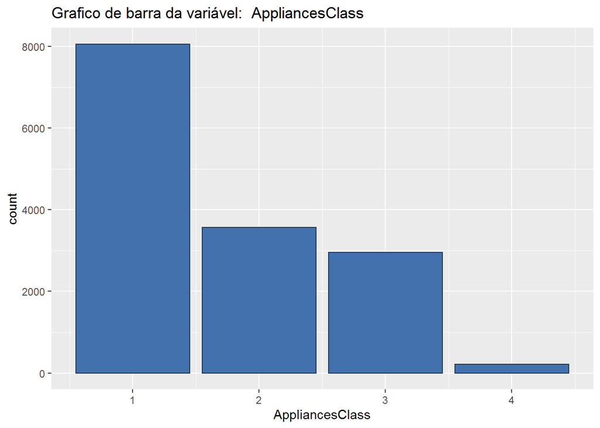

```r
# função para a criação do label de classificação
class_appliances  <- function(var) {
  if (var<=60 ){
    var = 1
  }
  else if (var > 60 & var <= 100){
    var = 2
  }
  else if (var > 100 & var <= 500){
    var = 3
  }
  else if (var > 500){
    var = 4
  }

}
# Crio a variável taget de classificação
# No de treino eu deixo junto ao DataFrame em uma nova coluna para o teste eu so vou salvar em uma variável sozinha.

df_train$AppliancesClass <- sapply(df_train$Appliances, class_appliances)
test_label <- sapply(df_test$Appliances, class_appliances)

# Imprimo a quantidade por classe
bar_plot(df_train, 'AppliancesClass')
```

```r
# Converto para factor a variável target adcionando os labels
df_train$AppliancesClass <- factor(df_train$AppliancesClass,levels = c(1,2,3,4))
test_label <- factor(test_label,levels = c(1,2,3,4))

# Imprimo as categorias
glimpse(df_train$AppliancesClass)
```

```
##  Factor w/ 4 levels "1","2","3","4": 1 1 1 1 1 1 1 2 3 3 ...
```

```r
glimpse(test_label)
```

```
##  Factor w/ 4 levels "1","2","3","4": 1 1 3 4 2 2 3 3 2 1 ...
```

```r
# Verifico se foi gerado algum valor nulo.
sum(is.na(df_train))
```

```
## [1] 0
```

```r
sum(is.na(df_test))
```

```
## [1] 0
```

```r
# Retiro as colunas que não serão necessárias.
df_train$date <- NULL
df_train$Appliances <- NULL
df_test$date <- NULL
df_test$Appliances <- NULL
```

```r
# Normalizo os dados de treino e teste.

names(df_train[,1:28])
```

```
##  [1] "lights"      "T1"          "RH_1"        "T2"          "RH_2"
##  [6] "T3"          "RH_3"        "T4"          "RH_4"        "T5"
## [11] "RH_5"        "T6"          "RH_6"        "T7"          "RH_7"
## [16] "T8"          "RH_8"        "T9"          "RH_9"        "T_out"
## [21] "Press_mm_hg" "RH_out"      "Windspeed"   "Visibility"  "Tdewpoint"
## [26] "rv1"         "rv2"         "NSM"
```

```r
names(df_test[,1:28])
```

```
##  [1] "lights"      "T1"          "RH_1"        "T2"          "RH_2"
##  [6] "T3"          "RH_3"        "T4"          "RH_4"        "T5"
## [11] "RH_5"        "T6"          "RH_6"        "T7"          "RH_7"
## [16] "T8"          "RH_8"        "T9"          "RH_9"        "T_out"
## [21] "Press_mm_hg" "RH_out"      "Windspeed"   "Visibility"  "Tdewpoint"
## [26] "rv1"         "rv2"         "NSM"
```

```r
df_train_norm <- as.data.frame(sapply(df_train[,1:28], normalize))
df_test_norm <- as.data.frame(sapply(df_test[,1:28], normalize))

# Adciono novamente as outra variáveis
train <- cbind(df_train_norm, df_train[,29:35])
test <- cbind(df_test_norm, df_test[,29:34])
```

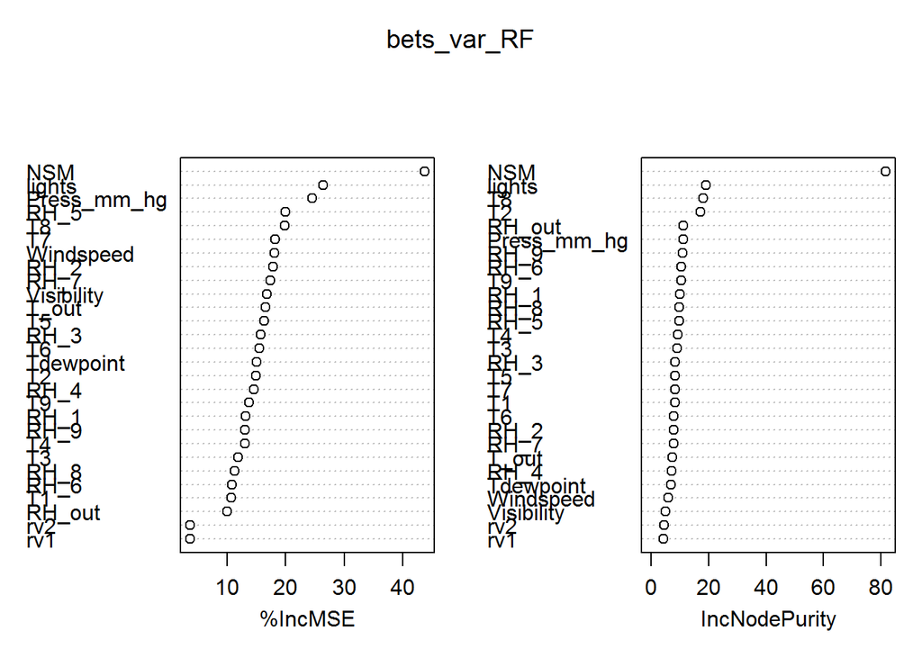

```r
# Uso o RandomForest para a seleção de variáveis

bets_var <- randomForest(AppliancesClass  ~ . ,data = train,
                            ntree = 100, nodesize = 10, importance = T)

varImpPlot(bets_var_RF)
```